# Introduction of Data Science Life Cycle

## Best Practices

- **Control module behavior for directly running and module import**

```python
class HotSkills:
    def __init__(self, hotskills=[], trainingdataset=None):
        self.hotskills = hotskills
        self.dataset = trainingdataset
    def get_hotskills(self):
        return self.hotskills

def main():
    # this function can be setup as standalone running codes
    # or as unit testing
    example = HotSkills(["bash","SQL"])
    print(example.get_hotskills())

# setup a control when directly running this module from python rather than import it to other module
if __name__ == "__main__":
    main()
```

```
['bash', 'SQL']
```

- **Use cache for faster value access**

```python
# Define a module for a data science model
import functools

class HotSkills:
    def __init__(self, hotskills=[], trainingdataset=None):
        self.hotskills = hotskills
        self.dataset = trainingdataset
    def get_hotskills(self):
        return self.hotskills

    @property
    # set this attribute value to be cached
    @functools.lru_cache()
    def hotskill_count(self):
        return len(self.hotskills)

def main():
    example = HotSkills(["bash","SQL"])
    print(example.hotskill_count)
    # for this time, the value of hotskill_count is from cached memory rather than calling len function
    print(example.hotskill_count)

# setup a control when directly running this module from python rather than import it to other module
if __name__ == "__main__":
    main()
```

```
2
2
```

- **Use Underscore and F-string to make a large number to be human readable and check-able**

```python
num1 = 10_000_000_000
num2 = 100_000_000

print(f'{num1+num2:,}')
```

```
10,100,000,000
```

- **Use** `zip` **function to combine multiple lists when needed**

```python
first_names = ['Ivan', 'Vikranth', 'Alyssa']
last_names = ['Chen', 'Ranga', 'Spitzer']

# unpacking zip data into two variables
for first_name, last_name in zip(first_names, last_names):
    print(f'{first_name}\'s last name is {last_name}')
```

```
Ivan's last name is Chen
Vikranth's last name is Ranga
Alyssa's last name is Spitzer
```

- **Use context manager to control resource behavior and garbage collection**

```python
with open('test.txt', 'r') as f:
    file_content = f.read()

words = file_content.split(" ")
words_count = len(words)
print(words)
print(words_count)
```

```
['This', 'is', 'a', 'test', 'file', 'and', 'it', 'contains', 'some', 'simple', 'text.']
11
```

- **Use string/list/tuple/dictionary comprehension to simplify codes**

```python
print([x*2 for x in range(5) if x > 2])

# avoid the following codes
for x in range(5):
    if x > 2:
        x*2
    else:
        pass
```

```
[6, 8]
```

- **Use simple condition statement to avoid unnecessary complexity**

```python
# Traditional approach
condition = True
if condition:
    x = 1
else:
    x = 0
print(x)
```

```
1
```

```python
# Simplified/Pythonic approach
condition = True
x = 1 if condition else 0
print(x)
```

```
1
```

# Version Control with Git

## Standards

The git repository of a data science model or project should contains at least following key components

- **README.md markdown file** to describe the model or project with following information:
  - Name of the model or project
  - The use cases, business scenario or purposes of creating this model or project
  - The prerequisites or assumptions of the model or project
  - The usage of the model or project
  - The constrains or limitations of the model or project
  - The deployment procedure, instruction and/or any notes
- **requirements.txt text file** to list all required python libraries that have been used in the model or project
- **datasets folder** to contain all the information about the data required by the model or project. They include:
  - SQL query files (with file extension name of .sql)
  - data sets for experiments (e.g. csv, parquet or Excel files)
- **notebooks folder** to contain all the jupyter notebooks that have been created for experimental and/or demo purposes
- **src folder** to contain all the source codes, including any Python codes (.py files), Shell codes (.sh files), Scala codes (.scala files) and etc.
- **releases folder** to contain the final (trained) models that can be deployed to the production environment and and deployment scripts that can be used to help/automate the deployment processes

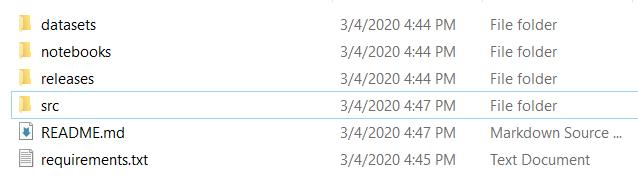

**Git Large File Storage (Git LFS)**

Git LFS (Large File Storage) is a Git extension developed by Atlassian, GitHub, and a few other open source contributors, that reduces the impact of large files in your repository by downloading the relevant versions of them lazily.

Git LFS is seamless: in your working copy you'll only see your actual file content. This means you can use Git LFS without changing your existing Git workflow; you simply git checkout, edit, git add, and git commit as normal. git clone and git pull operations will be significantly faster as you only download the versions of large files referenced by commits that you actually check out, rather than every version of the file that ever existed.

For the details about how to use Git LFS on BitBucket and GitHub, please refer to the link [here](https://www.atlassian.com/git/tutorials/git-lfs) and [here](https://git-lfs.github.com/)

## Best Practices

- **Commit Related Changes** A commit should be a wrapper for related changes.
- **Commit Often** Committing often keeps your commits small and, again, helps you commit only related changes.
- **Don’t Commit Half-Done Work** You should only commit code when it’s completed. This doesn’t mean you have to complete a whole, large feature before committing. Quite the contrary: split the feature’s implementation into logical chunks and remember to commit early and often.
- **Test Before You Commit** Resist the temptation to commit something that you “think” is completed. Test it thoroughly to make sure it really is completed and has no side effects (as far as one can tell).
- **Write Good Commit Messages** Begin your message with a short summary of your changes (up to 50 characters as a guideline). Separate it from the following body by including a blank line. The body of your message should provide detailed answers to the following questions: What was the motivation for the change? How does it differ from the previous implementation?
- **Version Control is not a Backup System** Having your files backed up on a remote server is a nice side effect of having a version control system. But you should not use your git repo like it was a backup system.
- **Use Branches** Branching is one of Git’s most powerful features – and this is not by accident: quick and easy branching was a central requirement from day one. Branches are the perfect tool to help you avoid mixing up different lines of development. You should use branches extensively in your development workflows: for new features, bug fixes, experiments, ideas…

# Productionalization

## Principles

- **Build Pipelines** Data science pipelines are sequences of processing and analysis steps applied to data for a specific purpose. They're useful in production projects, and they can also be useful if one expects to encounter the same type of business question in the future, so as to save on design time and coding. The following shows some common components for building pipelines.

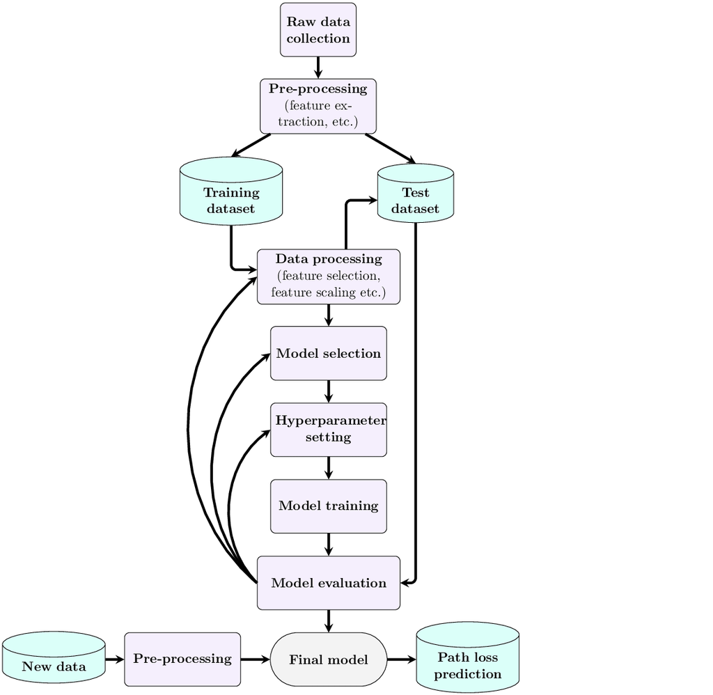

Pipelines are very common in Machine Learning systems, since there is a lot of data to manipulate and many data transformations to apply.

- **Model persistence** After model is completely trained and pipeline is built, we need to save the trained models or the whole pipeline in a file and restore them in order to reuse it to compare the model with other models, to test the model on a new data. The saving of data is called Serializaion, while restoring the data is called Deserialization. In Python, we generally store the binary representation of the model, using pickle or joblib.

## Best Practices

If the data keeps evolving, you will need to update your datasets and retrain your model regularly. You should probably automate the whole process as much as possible. Here are a few things you can automate:

- Collect fresh data regularly and label it (e.g., using human raters).
- Write a script to train the model and fine-tune the hyperparameters automatically. This script could run automatically, for example every day or every week, depending on your needs.
- Write another script that will evaluate both the new model and the previous model on the updated test set, and deploy the model to production if the performance has not decreased (if it did, make sure you investigate why).

An interesting article written by Google engineers is to discuss some techniques for implementing and automating continuous integration (CI), continuous delivery (CD), and continuous training (CT) for machine learning (ML) systems. Its link can be found [here](https://cloud.google.com/solutions/machine-learning/mlops-continuous-delivery-and-automation-pipelines-in-machine-learning), which is marked as [Extra Reading - Machine Learning Ops](https://cloud.google.com/solutions/machine-learning/mlops-continuous-delivery-and-automation-pipelines-in-machine-learning).

The following diagram shows the implementation of the ML pipeline using CI/CD, which has the characteristics of the automated ML pipelines setup plus the automated CI/CD routines.

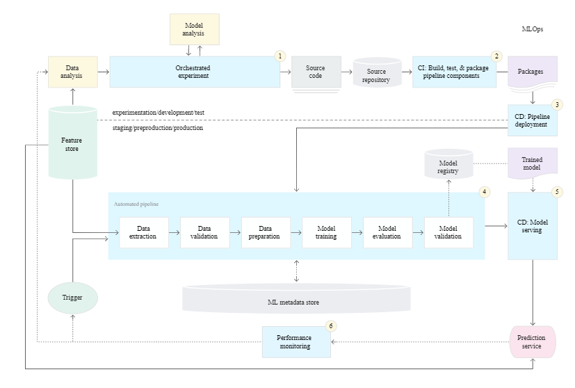

The following diagram shows the stages of the ML CI/CD automation pipeline:

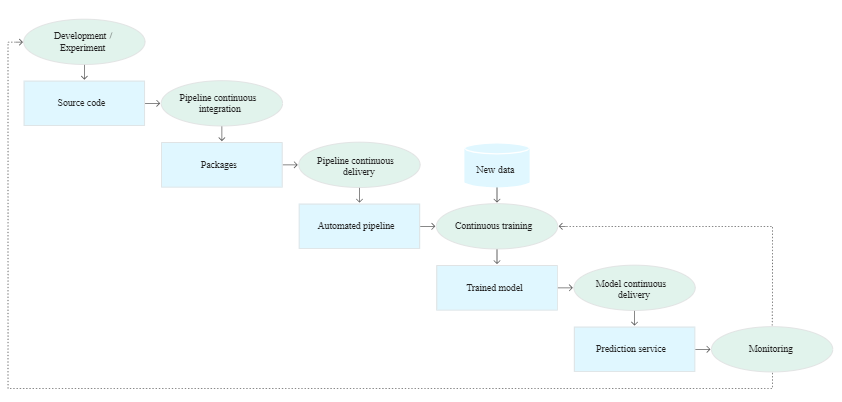

# Appendix

## Caching Decorator `lru_cache`

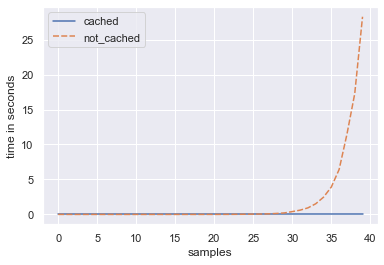

```python
from functools import lru_cache
from datetime import datetime

@lru_cache(maxsize=None)
def fib_cache(n):
    if n < 2:
        return n
    return fib_cache(n-1) + fib_cache(n-2)

def fib_no_cache(n):
    if n < 2:
        return n
    return fib_no_cache(n-1) + fib_no_cache(n-2)

def timeit(func,samples):
    start = datetime.now()
    func(samples)
    end = datetime.now()
    return end-start

UPPER = 40

cached = []
for i in range(0,UPPER):
    cached.append(timeit(fib_cache,i))

not_cached = []
for i in range(0,UPPER):
    not_cached.append(timeit(fib_no_cache,i))

import pandas as pd
import seaborn as sns

_ = pd.DataFrame([cached,not_cached]).T
_.columns = ['cached','not_cached']
_ = _.applymap(lambda x: x.value/1000000000)

sns.set()
g = sns.lineplot(data=_)
g.set_ylabel('time in seconds')
g.set_xlabel('samples')
```

## Machine Learning Categories

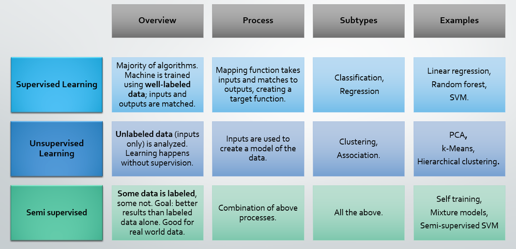